# RubricNet for Classical Guitar — Results Summary

**An interpretable, additive neural model for automatic difficulty estimation of classical guitar scores.**

This notebook walks through the headline results for my professor: dataset, the main accuracy/error comparison against Random Forest and fuzzy rule-based baselines, the confusion matrix, and the interpretability analysis that is the actual point of the thesis (an additive model that matches a black-box model while staying fully explainable).

All numbers below are loaded directly from the result files produced by the experiment scripts in `guitar/` — nothing here is hand-typed.

```python
import json
import pandas as pd
import numpy as np
import matplotlib.pyplot as plt
from pathlib import Path
from IPython.display import Image, display

ROOT = Path("..").resolve()
GUITAR = ROOT / "guitar"
FEATURES = ROOT / "features"
ASSETS = Path("assets")

plt.rcParams["figure.dpi"] = 110
plt.rcParams["axes.spines.top"] = False
plt.rcParams["axes.spines.right"] = False
```

## 1. Dataset

716 classical guitar pieces (MusicXML), each labeled with a difficulty grade on GuitarBurst's 1–20 scale. For classification, difficulty is binned into 8 equal-frequency classes (0 = easiest, 7 = hardest). The histogram below is computed live from the extracted feature table.

```
716 pieces, difficulty range 1-20
```

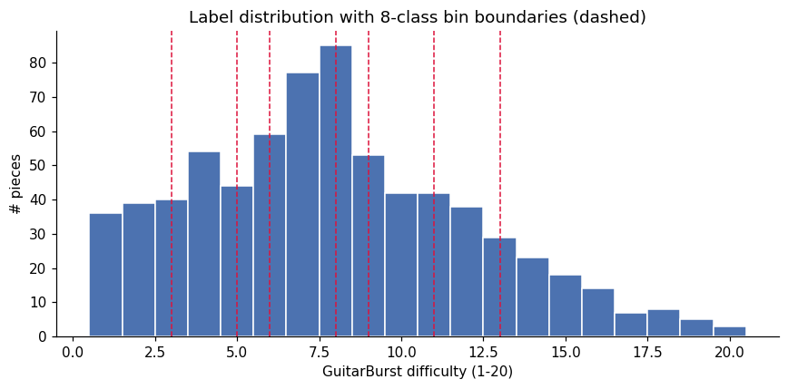

```python
df = pd.read_csv(FEATURES / "guitar_descriptors_v3.csv")
print(f"{len(df)} pieces, difficulty range {df['Difficulty'].min()}-{df['Difficulty'].max()}")

# Reconstruct the 8 equal-frequency class boundaries used for training
n_classes = 8
quantiles = np.linspace(0, 1, n_classes + 1)
edges = df["Difficulty"].quantile(quantiles).values

fig, ax = plt.subplots(figsize=(8, 4))
ax.hist(df["Difficulty"], bins=range(1, 22), align="left", color="#4C72B0", edgecolor="white")
for e in edges[1:-1]:
    ax.axvline(e, color="crimson", linestyle="--", linewidth=1)
ax.set_xlabel("GuitarBurst difficulty (1-20)")
ax.set_ylabel("# pieces")
ax.set_title("Label distribution with 8-class bin boundaries (dashed)")
plt.tight_layout()
plt.show()
```

## 2. Headline Result: RubricNet vs. Baselines (8-class, 5-fold, 3 seeds)

RubricNet is a strictly **additive** model: each hand-crafted descriptor gets its own tiny subnetwork, the outputs are summed, and an ordinal head turns the sum into a class prediction. There are no cross-descriptor interactions — that constraint is what makes it interpretable.

The comparison below pools results from:

- `guitar/rubricnet_results_v3.json` (RubricNet, 3 seeds × 5 folds)
- `guitar/baseline_results_v3.json` (Random Forest / Decision Tree / Ordinal Regression, 5 folds)
- `guitar/fuzzy_results_v3.json` (deterministic fuzzy rule-based classifiers, 5 folds)

```python
def mean_std(vals):
    vals = np.asarray(vals, dtype=float)
    return vals.mean(), vals.std()

rows = {}

# --- RubricNet V3 ---
rn = json.load(open(GUITAR / "rubricnet_results_v3.json"))["metrics"]
rows["RubricNet V3 (Ours)"] = {
    m: (rn[m]["mean"], rn[m]["std"])
    for m in ["accuracy", "balanced_accuracy", "acc_plus_minus_1", "mae", "mse", "kendall_tau"]
}

# --- Classical baselines (flat per-fold arrays, no kendall_tau / acc±1) ---
base = json.load(open(GUITAR / "baseline_results_v3.json"))
name_map = {"ordinal_regression": "Ordinal Regression V3",
            "decision_tree": "Decision Tree V3",
            "random_forest": "Random Forest V3"}
for key, label in name_map.items():
    d = base[key]
    rows[label] = {
        "accuracy": mean_std(d["accuracy"]),
        "balanced_accuracy": mean_std(d["balanced_accuracy"]),
        "acc_plus_minus_1": (np.nan, np.nan),
        "mae": mean_std(d["mae"]),
        "mse": mean_std(d["mse"]),
        "kendall_tau": (np.nan, np.nan),
    }

# --- Fuzzy rule-based classifiers ---
fuzzy = json.load(open(GUITAR / "fuzzy_results_v3.json"))
fuzzy_map = {"complete_search": "Fuzzy Rules (Complete Search) V3",
             "fuzzy_pattern_tree": "Fuzzy Pattern Tree V3"}
for key, label in fuzzy_map.items():
    s = fuzzy[key]["summary"]
    rows[label] = {m: (s[m]["mean"], s[m]["std"]) for m in
                   ["accuracy", "balanced_accuracy", "acc_plus_minus_1", "mae", "mse", "kendall_tau"]}

metric_labels = {"accuracy": "Accuracy", "balanced_accuracy": "Balanced Acc",
                  "acc_plus_minus_1": "Acc ± 1", "mae": "MAE", "mse": "MSE",
                  "kendall_tau": "Kendall τ"}

table = pd.DataFrame({
    metric_labels[m]: [f"{rows[r][m][0]:.3f} ± {rows[r][m][1]:.3f}" if not np.isnan(rows[r][m][0]) else "N/A"
                        for r in rows]
    for m in metric_labels
}, index=list(rows.keys()))

order = ["Ordinal Regression V3", "Decision Tree V3", "Random Forest V3",
         "Fuzzy Rules (Complete Search) V3", "Fuzzy Pattern Tree V3", "RubricNet V3 (Ours)"]
table = table.loc[order]
table
```

|  | Accuracy | Balanced Acc | Acc ± 1 | MAE | MSE | Kendall τ |
| --- | --- | --- | --- | --- | --- | --- |
| Ordinal Regression V3 | 0.309 ± 0.030 | 0.288 ± 0.030 | N/A | 1.109 ± 0.128 | 2.467 ± 0.681 | N/A |
| Decision Tree V3 | 0.279 ± 0.032 | 0.242 ± 0.031 | N/A | 1.286 ± 0.053 | 3.130 ± 0.439 | N/A |
| Random Forest V3 | 0.331 ± 0.019 | 0.289 ± 0.017 | N/A | 1.122 ± 0.064 | 2.527 ± 0.279 | N/A |
| Fuzzy Rules (Complete Search) V3 | 0.264 ± 0.044 | 0.236 ± 0.044 | 0.617 ± 0.068 | 1.433 ± 0.168 | 3.803 ± 0.597 | 0.464 ± 0.075 |
| Fuzzy Pattern Tree V3 | 0.268 ± 0.047 | 0.252 ± 0.041 | 0.623 ± 0.062 | 1.469 ± 0.207 | 4.233 ± 0.951 | 0.484 ± 0.063 |
| RubricNet V3 (Ours) | 0.310 ± 0.027 | 0.291 ± 0.028 | 0.733 ± 0.032 | 1.069 ± 0.063 | 2.147 ± 0.255 | 0.634 ± 0.026 |

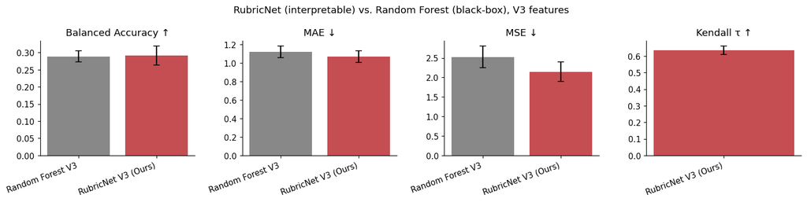

```python
highlight = ["Random Forest V3", "RubricNet V3 (Ours)"]
metrics_to_plot = ["balanced_accuracy", "mae", "mse", "kendall_tau"]
titles = ["Balanced Accuracy ↑", "MAE ↓", "MSE ↓", "Kendall τ ↑"]

fig, axes = plt.subplots(1, 4, figsize=(14, 3.5))
colors = {"Random Forest V3": "#888888", "RubricNet V3 (Ours)": "#C44E52"}
for ax, m, title in zip(axes, metrics_to_plot, titles):
    means = [rows[r][m][0] for r in highlight]
    stds = [rows[r][m][1] for r in highlight]
    bars = ax.bar(highlight, means, yerr=stds, capsize=4,
                   color=[colors[r] for r in highlight])
    ax.set_title(title)
    ax.set_xticklabels(highlight, rotation=20, ha="right")
fig.suptitle("RubricNet (interpretable) vs. Random Forest (black-box), V3 features")
plt.tight_layout()
plt.show()
```

## 3. Confusion Matrix

Pooled predictions on held-out test folds for RubricNet V3. Most errors are off-by-one confusions with adjacent difficulty classes, consistent with the accuracy-within-1 of ~0.73.

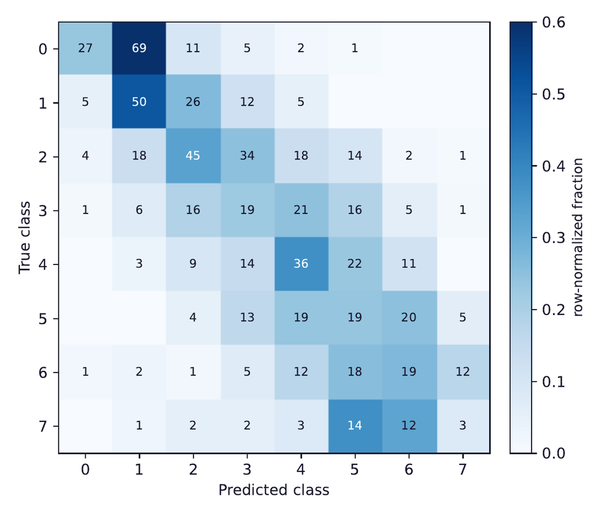

```python
display(Image(filename=str(ASSETS / "confusion_matrix_v3-1.png"), width=520))
```

## 4. Interpretability: Descriptor Importance & Monotonicity

This is the actual contribution of the thesis. Because RubricNet is additive (`score = sum_i g_i(x_i)`, no interaction terms), each descriptor's learned subnetwork `g_i` can be inspected directly.

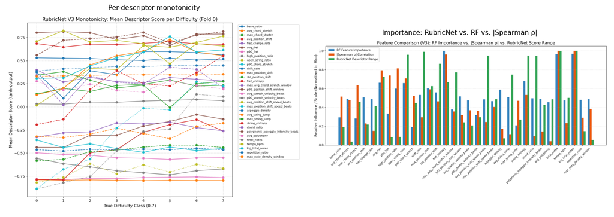

```python
fig, axes = plt.subplots(1, 2, figsize=(13, 5))
for ax, fname, title in zip(
    axes,
    ["monotonicity_v3.png", "importance_comparison_v3.png"],
    ["Per-descriptor monotonicity", "Importance: RubricNet vs. RF vs. |Spearman ρ|"],
):
    img = plt.imread(GUITAR / "figures" / fname)
    ax.imshow(img)
    ax.axis("off")
    ax.set_title(title, fontsize=10)
plt.tight_layout()
plt.show()
```

**Top 5 most influential descriptors (by output range on the test set), RubricNet V3:**

1. `log_total_notes` — overall piece length/density
2. `total_notes` — overall piece length/density
3. `shift_rate` — how often the fretting hand changes position
4. `open_string_ratio` — use of open strings (negative weight: more open strings -> easier)
5. `string_entropy` — right-hand string-crossing variety

These match established classical-guitar pedagogy (position shifts, open-string usage, and right-hand variety are textbook difficulty drivers), which is the qualitative validation for the quantitative importance-alignment plot above.

## 5. Per-Piece Rubric: What the Model Actually Says

Because the model is additive, a single prediction decomposes into a literal, readable rubric: one signed contribution per descriptor. Below is that breakdown for an easy piece (Sor, *Andantino* Op. 35 No. 2, difficulty level 1) against a hard piece (Bach, *Chaconne* BWV 1004, difficulty level 19).

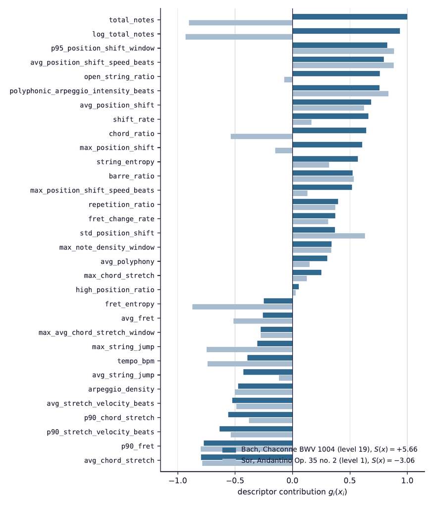

```python
display(Image(filename=str(ASSETS / "rubric_example-1.png"), width=680))
```

## 6. Fuzzy Rule-Based Baselines

As a second, independent interpretable baseline (adapted from Heerde, Vatolkin & Rudolph, EvoMUSART 2020), I also implemented deterministic fuzzy rule classifiers: descriptors are fuzzified into 5 triangular linguistic terms (very low ... very high), and classification is either a complete search over primitive rules or a fuzzy pattern tree (FPT).

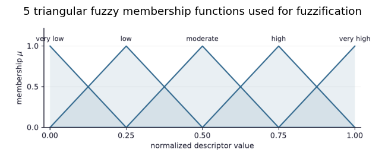

```python
img = plt.imread(ASSETS / "membership_functions-1.png")
fig, ax = plt.subplots(figsize=(6, 3.2))
ax.imshow(img)
ax.axis("off")
ax.set_title("5 triangular fuzzy membership functions used for fuzzification")
plt.tight_layout()
plt.show()
```

These are considerably weaker than RubricNet on every metric (see table in §2), but they provide a second interpretability sanity check: the top rules for the easiest class cite low fret position, small stretches, and stable hand position; the top rules for the hardest class cite the opposite plus high note count — qualitatively the same story RubricNet's descriptor weights tell.

## 7. Coarse 3-Class Check (Easy / Medium / Hard)

Collapsing the 8 classes down to 3 broad bands shows the model is learning real trends, not just exploiting fine-grained bin edges.

```python
coarse = rn["coarse_3class"]
coarse_acc = mean_std(coarse["accuracy"])
coarse_bacc = mean_std(coarse["balanced_accuracy"])
coarse_table = pd.DataFrame({
    "Accuracy": [f"{coarse_acc[0]:.3f} ± {coarse_acc[1]:.3f}"],
    "Balanced Accuracy": [f"{coarse_bacc[0]:.3f} ± {coarse_bacc[1]:.3f}"],
}, index=["RubricNet V3 (Coarse 3-class)"])
coarse_table
```

|  | Accuracy | Balanced Accuracy |
| --- | --- | --- |
| RubricNet V3 (Coarse 3-class) | 0.676 ± 0.032 | 0.614 ± 0.050 |